**City College of San Francisco**

MATH 108 - Foundations of Data Science

# Lecture 17: Comparing Distributions

Associated Textbook Sections: [11.1, 11.2](https://inferentialthinking.com/chapters/11/2/Multiple_Categories.html)

## Set Up the Notebook

```python
from datascience import *
import numpy as np
%matplotlib inline
import matplotlib.pyplot as plots
plots.style.use('fivethirtyeight')
```

## Comparing Distributions

### Jury Selection in Alameda County

[figure not shown]

Report Source: [ACLU of Northern California - RACIAL AND ETHNIC DISPARITIES IN ALAMEDA COUNTY JURY POOLS (2010)](https://www.aclunc.org/sites/default/files/racial_and_ethnic_disparities_in_alameda_county_jury_pools.pdf)

### Jury Panels

[figure not shown]

Section 197 of California's Code of Civil Procedure says,

> "All persons selected for jury service shall be selected at random, from a source or sources inclusive of a representative cross section of the population of the area served by the court."

### Demo: Alameda County Jury Panels

Visualize the the eligible and panel distributions of ethnicities based on the Totals in the report.

```python
jury = Table().with_columns(
    'Ethnicity', make_array('Asian/PI ', 'Black/AA', 'Hispanic ', 'Caucasian', 'Other'),
    'Eligible', make_array(0.15, 0.18, 0.12, 0.54, 0.01),
    'Panels', make_array(0.26, 0.08, 0.08, 0.54, 0.04)
)

jury
```

| Ethnicity | Eligible | Panels |
| --- | --- | --- |
| Asian/PI | 0.15 | 0.26 |
| Black/AA | 0.18 | 0.08 |
| Hispanic | 0.12 | 0.08 |
| Caucasian | 0.54 | 0.54 |
| Other | 0.01 | 0.04 |

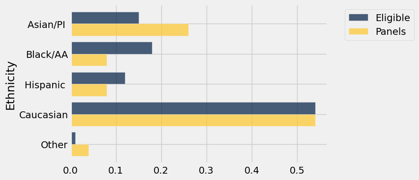

```python
jury.barh('Ethnicity')
```

Under the model, define an array that represents the distribution of people from which the jurors are randomly sampled

```python
model_props = make_array(0.15, 0.18, 0.12, 0.54, 0.01)
model_props
```

```
array([ 0.15,  0.18,  0.12,  0.54,  0.01])
```

Simulate a random draw of 1423 jurors from this distribution

```python
simulated = sample_proportions(1423, model_props)
simulated
```

```
array([ 0.15460295,  0.1848208 ,  0.11876318,  0.53056922,  0.01124385])
```

The actual observed distribution (Panels) looks quite different from the simulation -- try simulating this several times to confirm!

```python
jury_with_simulated = jury.with_column('Simulated', simulated)
jury_with_simulated
```

| Ethnicity | Eligible | Panels | Simulated |
| --- | --- | --- | --- |
| Asian/PI | 0.15 | 0.26 | 0.154603 |
| Black/AA | 0.18 | 0.08 | 0.184821 |
| Hispanic | 0.12 | 0.08 | 0.118763 |
| Caucasian | 0.54 | 0.54 | 0.530569 |
| Other | 0.01 | 0.04 | 0.0112439 |

Visualize the results of the last simulation.

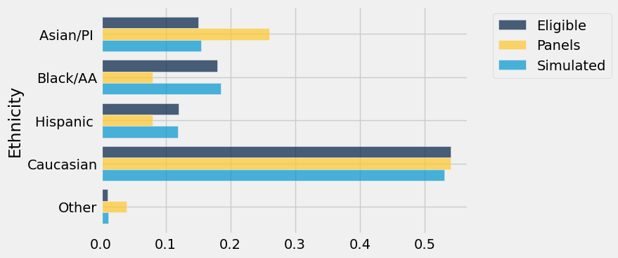

```python
jury_with_simulated.barh('Ethnicity')
```

## A New Statistic

### Distance Between Distributions

- People on the panels are of multiple ethnicities
- Distribution of ethnicities is categorical
- To see whether the the distribution of ethnicities of the panels is close to that of the eligible jurors, we have to measure the distance between two categorical distributions

### Demo: Distance Between Distributions

In the last lecture, the difference between observed black/purple and their expected values (26%/75%) was our statistic. In this case, we need to understand how each of the 5 categories differ from their expected values according to the model.

```python
diffs = jury.column('Panels') - jury.column('Eligible')
jury.with_column('Difference', diffs)
```

| Ethnicity | Eligible | Panels | Difference |
| --- | --- | --- | --- |
| Asian/PI | 0.15 | 0.26 | 0.11 |
| Black/AA | 0.18 | 0.08 | -0.1 |
| Hispanic | 0.12 | 0.08 | -0.04 |
| Caucasian | 0.54 | 0.54 | 0 |
| Other | 0.01 | 0.04 | 0.03 |

### Total Variation Distance

Total Variation Distance (TVD) Recipe:

- For each category, compute the difference in proportions between two distributions
- Take the absolute value of each difference
- Sum, and then divide the sum by 2

### Demo: Total Variation Distance

Define a function that calculates the TVD for two distributions inputed as arrays.

```python
def tvd(dist1, dist2):
    return sum(abs(dist1 - dist2)) / 2
```

Calculate the TVD of our observed data (Panels) from their expected values assuming the model is true (Eligbible)

```python
observed_tvd = tvd(jury.column('Panels'), jury.column('Eligible'))
observed_tvd
```

```
0.14000000000000001
```

Calculate the TVD of a model simulation from its expected values

```python
sample_panel = sample_proportions(1423, model_props)
tvd(sample_panel, model_props)
```

```
0.01958538299367537
```

Replicate creating sample juries and calculated the TVD in relation to the model 10000 times. Visualize how the observed statistic fits in the distribution formed from those simulated TVD values.

```python
def simulated_tvd():
    sample_panel = sample_proportions(1423, model_props)
    return tvd(sample_panel, model_props)

tvds = make_array()

for _ in np.arange(10000):
    new_tvd = simulated_tvd()
    tvds = np.append(tvds, new_tvd)
```

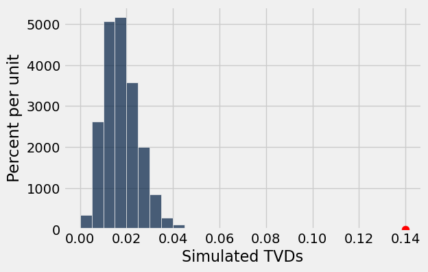

```python
Table().with_column('Simulated TVDs', tvds).hist(bins = np.arange(0, 0.05, 0.005))
plots.scatter(observed_tvd, 0, color='red', s=60, zorder=3)
plots.show()
```

# Continue at 7:32

### Summary of the Method

To assess whether a sample was drawn randomly from a known categorical distribution:

- Use TVD as the statistic because it measures the distance between categorical distributions
- Sample at random from the population and compute the TVD from the random sample; repeat numerous times
- Compare:
  - Empirical distribution of simulated TVDs
  - Actual TVD from the sample in the study

## Testing Hypotheses

### Testing Hypotheses

- A test chooses between two views of how data were generated
- The views are called hypotheses
- The test picks the hypothesis that is better supported by the observed data

### Null and Alternative

The method only works if we can simulate data under one of the hypotheses.

- Null hypothesis:
  - A well defined chance model about how the data were generated
  - We can simulate data under the assumptions of this model – “under the null hypothesis”
- Alternative hypothesis: A different view about the origin of the data

### Test Statistic

- The statistic that we choose to simulate, to decide between the two hypotheses
- Questions before choosing the statistic:
  - What values of the statistic will make us lean towards the null hypothesis?
  - What values will make us lean towards the alternative? Preferably, the answer should be just "high". Try to avoid "both high and low".

### Prediction Under the Null Hypothesis

- Simulate the test statistic under the null hypothesis; draw the histogram of the simulated values
- This displays the **empirical distribution of the statistic under the null hypothesis**
- It is a prediction about the statistic, made by the null hypothesis
  - It shows all the likely values of the statistic
  - Also how likely they are (**if the null hypothesis is true**)
- The probabilities are approximate, because we can't generate all the possible random samples

### Conclusion of the Test

- Resolve choice between null and alternative hypotheses
  - Compare the **observed test statistic** and its empirical distribution under the null hypothesis
  - If the observed value is **not consistent** with the distribution, then the test favors the alternative ("data is more consistent with the alternative")
- Whether a value is consistent with a distribution:
  - A visualization may be sufficient
  - If not, there are conventions about "consistency"